# Risk Factor Analysis

## Outcome Variable

**Outcome Variable:** whz

## Predictor Variables

**Intervention Variable:** single

**Adjustment Set:**

- arm
- W_mage
- meducyrs
- feducyrs
- W_mhtcm
- W_mwtkg
- W_mbmi
- delta_W_mage
- delta_meducyrs
- delta_feducyrs
- delta_W_mhtcm
- delta_W_mwtkg
- delta_W_mbmi

## Stratifying Variables

The analysis was stratified on these variable(s):

- agecat
- studyid
- country

## Data Summary

| agecat | studyid | country | single | n_cell | n |
| --- | --- | --- | --- | --- | --- |
| Birth | ki0047075b-MAL-ED | BANGLADESH | 0 | 215 | 215 |
| Birth | ki0047075b-MAL-ED | BANGLADESH | 1 | 0 | 215 |
| Birth | ki0047075b-MAL-ED | BRAZIL | 0 | 54 | 62 |
| Birth | ki0047075b-MAL-ED | BRAZIL | 1 | 8 | 62 |
| Birth | ki0047075b-MAL-ED | INDIA | 0 | 45 | 45 |
| Birth | ki0047075b-MAL-ED | INDIA | 1 | 0 | 45 |
| Birth | ki0047075b-MAL-ED | NEPAL | 0 | 26 | 26 |
| Birth | ki0047075b-MAL-ED | NEPAL | 1 | 0 | 26 |
| Birth | ki0047075b-MAL-ED | PERU | 0 | 205 | 228 |
| Birth | ki0047075b-MAL-ED | PERU | 1 | 23 | 228 |
| Birth | ki0047075b-MAL-ED | SOUTH AFRICA | 0 | 63 | 120 |
| Birth | ki0047075b-MAL-ED | SOUTH AFRICA | 1 | 57 | 120 |
| Birth | ki0047075b-MAL-ED | TANZANIA, UNITED REPUBLIC OF | 0 | 112 | 115 |
| Birth | ki0047075b-MAL-ED | TANZANIA, UNITED REPUBLIC OF | 1 | 3 | 115 |
| Birth | ki1119695-PROBIT | BELARUS | 0 | 13291 | 13830 |
| Birth | ki1119695-PROBIT | BELARUS | 1 | 539 | 13830 |
| Birth | ki1126311-ZVITAMBO | ZIMBABWE | 0 | 12065 | 12864 |
| Birth | ki1126311-ZVITAMBO | ZIMBABWE | 1 | 799 | 12864 |
| Birth | ki1135781-COHORTS | GUATEMALA | 0 | 654 | 691 |
| Birth | ki1135781-COHORTS | GUATEMALA | 1 | 37 | 691 |
| Birth | ki1135781-COHORTS | INDIA | 0 | 4456 | 4463 |
| Birth | ki1135781-COHORTS | INDIA | 1 | 7 | 4463 |
| Birth | ki1135781-COHORTS | PHILIPPINES | 0 | 2789 | 2860 |
| Birth | ki1135781-COHORTS | PHILIPPINES | 1 | 71 | 2860 |
| Birth | kiGH5241-JiVitA-4 | BANGLADESH | 0 | 2388 | 2393 |
| Birth | kiGH5241-JiVitA-4 | BANGLADESH | 1 | 5 | 2393 |
| 6 months | ki0047075b-MAL-ED | BANGLADESH | 0 | 241 | 241 |
| 6 months | ki0047075b-MAL-ED | BANGLADESH | 1 | 0 | 241 |
| 6 months | ki0047075b-MAL-ED | BRAZIL | 0 | 179 | 209 |
| 6 months | ki0047075b-MAL-ED | BRAZIL | 1 | 30 | 209 |

[output cut: 54 more lines]

The following strata were considered:

- agecat: 24 months, studyid: ki0047075b-MAL-ED, country: BANGLADESH
- agecat: 24 months, studyid: ki0047075b-MAL-ED, country: BRAZIL
- agecat: 24 months, studyid: ki0047075b-MAL-ED, country: INDIA
- agecat: 24 months, studyid: ki0047075b-MAL-ED, country: NEPAL
- agecat: 24 months, studyid: ki0047075b-MAL-ED, country: PERU
- agecat: 24 months, studyid: ki0047075b-MAL-ED, country: SOUTH AFRICA
- agecat: 24 months, studyid: ki0047075b-MAL-ED, country: TANZANIA, UNITED REPUBLIC OF
- agecat: 24 months, studyid: ki1066203-TanzaniaChild2, country: TANZANIA, UNITED REPUBLIC OF
- agecat: 24 months, studyid: ki1119695-PROBIT, country: BELARUS
- agecat: 24 months, studyid: ki1126311-ZVITAMBO, country: ZIMBABWE
- agecat: 24 months, studyid: ki1135781-COHORTS, country: GUATEMALA
- agecat: 24 months, studyid: ki1135781-COHORTS, country: INDIA
- agecat: 24 months, studyid: ki1135781-COHORTS, country: PHILIPPINES
- agecat: 24 months, studyid: kiGH5241-JiVitA-4, country: BANGLADESH
- agecat: 6 months, studyid: ki0047075b-MAL-ED, country: BANGLADESH
- agecat: 6 months, studyid: ki0047075b-MAL-ED, country: BRAZIL
- agecat: 6 months, studyid: ki0047075b-MAL-ED, country: INDIA
- agecat: 6 months, studyid: ki0047075b-MAL-ED, country: NEPAL
- agecat: 6 months, studyid: ki0047075b-MAL-ED, country: PERU
- agecat: 6 months, studyid: ki0047075b-MAL-ED, country: SOUTH AFRICA
- agecat: 6 months, studyid: ki0047075b-MAL-ED, country: TANZANIA, UNITED REPUBLIC OF
- agecat: 6 months, studyid: ki1066203-TanzaniaChild2, country: TANZANIA, UNITED REPUBLIC OF
- agecat: 6 months, studyid: ki1112895-Guatemala BSC, country: GUATEMALA
- agecat: 6 months, studyid: ki1119695-PROBIT, country: BELARUS
- agecat: 6 months, studyid: ki1126311-ZVITAMBO, country: ZIMBABWE
- agecat: 6 months, studyid: ki1135781-COHORTS, country: GUATEMALA
- agecat: 6 months, studyid: ki1135781-COHORTS, country: INDIA
- agecat: 6 months, studyid: ki1135781-COHORTS, country: PHILIPPINES
- agecat: 6 months, studyid: kiGH5241-JiVitA-4, country: BANGLADESH
- agecat: Birth, studyid: ki0047075b-MAL-ED, country: BANGLADESH
- agecat: Birth, studyid: ki0047075b-MAL-ED, country: BRAZIL
- agecat: Birth, studyid: ki0047075b-MAL-ED, country: INDIA
- agecat: Birth, studyid: ki0047075b-MAL-ED, country: NEPAL
- agecat: Birth, studyid: ki0047075b-MAL-ED, country: PERU
- agecat: Birth, studyid: ki0047075b-MAL-ED, country: SOUTH AFRICA
- agecat: Birth, studyid: ki0047075b-MAL-ED, country: TANZANIA, UNITED REPUBLIC OF
- agecat: Birth, studyid: ki1119695-PROBIT, country: BELARUS
- agecat: Birth, studyid: ki1126311-ZVITAMBO, country: ZIMBABWE
- agecat: Birth, studyid: ki1135781-COHORTS, country: GUATEMALA
- agecat: Birth, studyid: ki1135781-COHORTS, country: INDIA
- agecat: Birth, studyid: ki1135781-COHORTS, country: PHILIPPINES
- agecat: Birth, studyid: kiGH5241-JiVitA-4, country: BANGLADESH

### Dropped Strata

- agecat: Birth, studyid: ki0047075b-MAL-ED, country: BANGLADESH
- agecat: Birth, studyid: ki0047075b-MAL-ED, country: INDIA
- agecat: Birth, studyid: ki0047075b-MAL-ED, country: NEPAL
- agecat: Birth, studyid: ki0047075b-MAL-ED, country: TANZANIA, UNITED REPUBLIC OF
- agecat: 6 months, studyid: ki0047075b-MAL-ED, country: BANGLADESH
- agecat: 6 months, studyid: ki0047075b-MAL-ED, country: INDIA
- agecat: 6 months, studyid: ki0047075b-MAL-ED, country: NEPAL
- agecat: 24 months, studyid: ki0047075b-MAL-ED, country: BANGLADESH
- agecat: 24 months, studyid: ki0047075b-MAL-ED, country: INDIA
- agecat: 24 months, studyid: ki0047075b-MAL-ED, country: NEPAL
- agecat: 24 months, studyid: ki1066203-TanzaniaChild2, country: TANZANIA, UNITED REPUBLIC OF

## Methods Detail

We’re interested in the causal parameters $E[Y_a]$ for all values of $a \in \mathcal{A}$. These parameters represent the mean outcome if, possibly contrary to fact, we intervened to set all units to have $A=a$. Under the randomization and positivity assumptions, these are identified by the statistical parameters $\psi_a=E_W[E_{Y|A,W}(Y|A=a,W)]$. In addition, we’re interested in the mean of $Y$, $E[Y]$ under no intervention (the observed mean). We will estimate these parameters by using SuperLearner to fit the relevant likelihood factors – $E_{Y|A,W}(Y|A=a,W)$ and $p(A=a|W)$, and then updating our likelihood fit using a joint TMLE.

For unadjusted analyses ($W=\{\}$), initial likelihoods were estimated using Lrnr_glm to estimate the simple $E(Y|A)$ and Lrnr_mean to estimate $p(A)$. For adjusted analyses, a small library containing Lrnr_glmnet, Lrnr_xgboost, and Lrnr_mean was used.

Having estimated these parameters, we will then use the delta method to estimate relative risks and attributable risks relative to a prespecified baseline level of $A$.

# Results Detail

## Results Plots

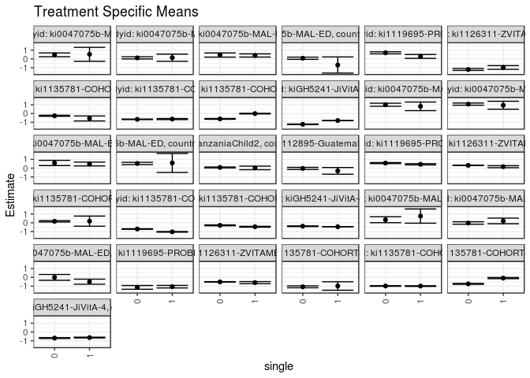

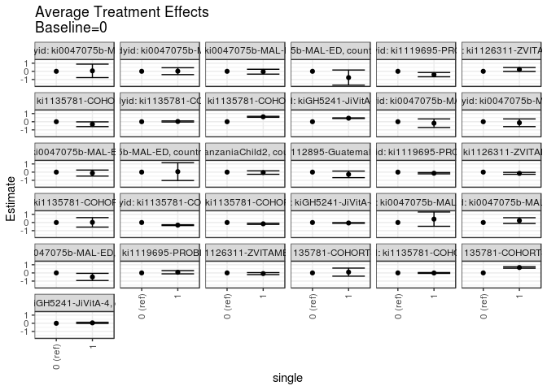

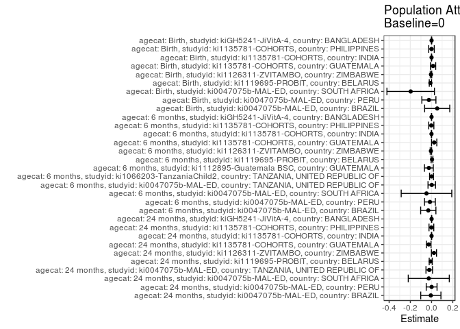

## Results Table

### Parameter: TSM

| agecat | studyid | country | intervention_level | baseline_level | estimate | ci_lower | ci_upper |
| --- | --- | --- | --- | --- | --- | --- | --- |
| Birth | ki0047075b-MAL-ED | BRAZIL | 0 | NA | 0.3496296 | 0.0129664 | 0.6862928 |
| Birth | ki0047075b-MAL-ED | BRAZIL | 1 | NA | 0.7625000 | -0.0474852 | 1.5724852 |
| Birth | ki0047075b-MAL-ED | PERU | 0 | NA | -0.0268675 | -0.1691164 | 0.1153814 |
| Birth | ki0047075b-MAL-ED | PERU | 1 | NA | 0.2099812 | -0.1105995 | 0.5305620 |
| Birth | ki0047075b-MAL-ED | SOUTH AFRICA | 0 | NA | 0.0042269 | -0.3225348 | 0.3309885 |
| Birth | ki0047075b-MAL-ED | SOUTH AFRICA | 1 | NA | -0.4880438 | -0.7746811 | -0.2014064 |
| Birth | ki1119695-PROBIT | BELARUS | 0 | NA | -1.1340703 | -1.3467771 | -0.9213634 |
| Birth | ki1119695-PROBIT | BELARUS | 1 | NA | -1.0543331 | -1.1981805 | -0.9104858 |
| Birth | ki1126311-ZVITAMBO | ZIMBABWE | 0 | NA | -0.5095465 | -0.5363515 | -0.4827414 |
| Birth | ki1126311-ZVITAMBO | ZIMBABWE | 1 | NA | -0.5940642 | -0.7144357 | -0.4736928 |
| Birth | ki1135781-COHORTS | GUATEMALA | 0 | NA | -1.0693322 | -1.1790562 | -0.9596081 |
| Birth | ki1135781-COHORTS | GUATEMALA | 1 | NA | -0.9754235 | -1.4569647 | -0.4938824 |
| Birth | ki1135781-COHORTS | INDIA | 0 | NA | -0.9764901 | -1.0121932 | -0.9407871 |
| Birth | ki1135781-COHORTS | INDIA | 1 | NA | -0.9871429 | -1.0249916 | -0.9492941 |
| Birth | ki1135781-COHORTS | PHILIPPINES | 0 | NA | -0.7372579 | -0.7924291 | -0.6820867 |
| Birth | ki1135781-COHORTS | PHILIPPINES | 1 | NA | -0.0773314 | -0.1437884 | -0.0108743 |
| Birth | kiGH5241-JiVitA-4 | BANGLADESH | 0 | NA | -0.6889322 | -0.7427226 | -0.6351417 |
| Birth | kiGH5241-JiVitA-4 | BANGLADESH | 1 | NA | -0.6340000 | -0.6780019 | -0.5899981 |
| 6 months | ki0047075b-MAL-ED | BRAZIL | 0 | NA | 1.0025549 | 0.8261401 | 1.1789698 |
| 6 months | ki0047075b-MAL-ED | BRAZIL | 1 | NA | 0.8192390 | 0.3279318 | 1.3105461 |
| 6 months | ki0047075b-MAL-ED | PERU | 0 | NA | 1.0723468 | 0.9455643 | 1.1991293 |
| 6 months | ki0047075b-MAL-ED | PERU | 1 | NA | 0.9444026 | 0.4926717 | 1.3961335 |
| 6 months | ki0047075b-MAL-ED | SOUTH AFRICA | 0 | NA | 0.5906174 | 0.2927001 | 0.8885347 |
| 6 months | ki0047075b-MAL-ED | SOUTH AFRICA | 1 | NA | 0.4736295 | 0.2553630 | 0.6918960 |
| 6 months | ki0047075b-MAL-ED | TANZANIA, UNITED REPUBLIC OF | 0 | NA | 0.5343375 | 0.4035792 | 0.6650959 |
| 6 months | ki0047075b-MAL-ED | TANZANIA, UNITED REPUBLIC OF | 1 | NA | 0.5925000 | -0.4882365 | 1.6732365 |
| 6 months | ki1066203-TanzaniaChild2 | TANZANIA, UNITED REPUBLIC OF | 0 | NA | 0.0802173 | 0.0254331 | 0.1350016 |
| 6 months | ki1066203-TanzaniaChild2 | TANZANIA, UNITED REPUBLIC OF | 1 | NA | 0.0260460 | -0.1774384 | 0.2295305 |
| 6 months | ki1112895-Guatemala BSC | GUATEMALA | 0 | NA | -0.0315047 | -0.1528202 | 0.0898107 |
| 6 months | ki1112895-Guatemala BSC | GUATEMALA | 1 | NA | -0.3086965 | -0.6908589 | 0.0734658 |
| 6 months | ki1119695-PROBIT | BELARUS | 0 | NA | 0.5749507 | 0.5158464 | 0.6340551 |
| 6 months | ki1119695-PROBIT | BELARUS | 1 | NA | 0.4390415 | 0.3697589 | 0.5083242 |
| 6 months | ki1126311-ZVITAMBO | ZIMBABWE | 0 | NA | 0.3169253 | 0.2903691 | 0.3434815 |
| 6 months | ki1126311-ZVITAMBO | ZIMBABWE | 1 | NA | 0.1661943 | 0.0523350 | 0.2800536 |
| 6 months | ki1135781-COHORTS | GUATEMALA | 0 | NA | 0.1672559 | 0.0910378 | 0.2434739 |
| 6 months | ki1135781-COHORTS | GUATEMALA | 1 | NA | 0.1859888 | -0.3900646 | 0.7620421 |
| 6 months | ki1135781-COHORTS | INDIA | 0 | NA | -0.7098951 | -0.7430287 | -0.6767615 |
| 6 months | ki1135781-COHORTS | INDIA | 1 | NA | -1.0322222 | -1.0700926 | -0.9943519 |
| 6 months | ki1135781-COHORTS | PHILIPPINES | 0 | NA | -0.2913002 | -0.3404647 | -0.2421356 |
| 6 months | ki1135781-COHORTS | PHILIPPINES | 1 | NA | -0.4512531 | -0.4992089 | -0.4032973 |
| 6 months | kiGH5241-JiVitA-4 | BANGLADESH | 0 | NA | -0.3903686 | -0.4286532 | -0.3520840 |
| 6 months | kiGH5241-JiVitA-4 | BANGLADESH | 1 | NA | -0.4493750 | -0.4619543 | -0.4367957 |
| 24 months | ki0047075b-MAL-ED | BRAZIL | 0 | NA | 0.4661000 | 0.2509701 | 0.6812298 |
| 24 months | ki0047075b-MAL-ED | BRAZIL | 1 | NA | 0.5224819 | -0.2673358 | 1.3122996 |
| 24 months | ki0047075b-MAL-ED | PERU | 0 | NA | 0.1197637 | -0.0042652 | 0.2437925 |
| 24 months | ki0047075b-MAL-ED | PERU | 1 | NA | 0.1376138 | -0.2700746 | 0.5453022 |
| 24 months | ki0047075b-MAL-ED | SOUTH AFRICA | 0 | NA | 0.4411267 | 0.2054860 | 0.6767674 |
| 24 months | ki0047075b-MAL-ED | SOUTH AFRICA | 1 | NA | 0.3930416 | 0.2112394 | 0.5748439 |
| 24 months | ki0047075b-MAL-ED | TANZANIA, UNITED REPUBLIC OF | 0 | NA | 0.0755048 | -0.0493112 | 0.2003208 |
| 24 months | ki0047075b-MAL-ED | TANZANIA, UNITED REPUBLIC OF | 1 | NA | -0.6933333 | -1.6135001 | 0.2268334 |
| 24 months | ki1119695-PROBIT | BELARUS | 0 | NA | 0.6951616 | 0.5780749 | 0.8122483 |
| 24 months | ki1119695-PROBIT | BELARUS | 1 | NA | 0.2885520 | 0.0677395 | 0.5093646 |
| 24 months | ki1126311-ZVITAMBO | ZIMBABWE | 0 | NA | -1.2024734 | -1.3095013 | -1.0954454 |
| 24 months | ki1126311-ZVITAMBO | ZIMBABWE | 1 | NA | -0.9745617 | -1.1854626 | -0.7636608 |
| 24 months | ki1135781-COHORTS | GUATEMALA | 0 | NA | -0.2527155 | -0.3100691 | -0.1953619 |
| 24 months | ki1135781-COHORTS | GUATEMALA | 1 | NA | -0.5584360 | -0.8442119 | -0.2726602 |
| 24 months | ki1135781-COHORTS | INDIA | 0 | NA | -0.6594835 | -0.6934635 | -0.6255034 |
| 24 months | ki1135781-COHORTS | INDIA | 1 | NA | -0.6300000 | -0.6887577 | -0.5712423 |
| 24 months | ki1135781-COHORTS | PHILIPPINES | 0 | NA | -0.6085174 | -0.6525551 | -0.5644796 |
| 24 months | ki1135781-COHORTS | PHILIPPINES | 1 | NA | -0.0068485 | -0.0431566 | 0.0294596 |
| 24 months | kiGH5241-JiVitA-4 | BANGLADESH | 0 | NA | -1.2245351 | -1.2573027 | -1.1917674 |
| 24 months | kiGH5241-JiVitA-4 | BANGLADESH | 1 | NA | -0.7950000 | -0.8090439 | -0.7809561 |

### Parameter: E(Y)

| agecat | studyid | country | intervention_level | baseline_level | estimate | ci_lower | ci_upper |
| --- | --- | --- | --- | --- | --- | --- | --- |
| Birth | ki0047075b-MAL-ED | BRAZIL | NA | NA | 0.4029032 | 0.0896793 | 0.7161272 |
| Birth | ki0047075b-MAL-ED | PERU | NA | NA | -0.0520175 | -0.1725298 | 0.0684947 |
| Birth | ki0047075b-MAL-ED | SOUTH AFRICA | NA | NA | -0.1925833 | -0.4053570 | 0.0201904 |
| Birth | ki1119695-PROBIT | BELARUS | NA | NA | -1.1448633 | -1.3544229 | -0.9353037 |
| Birth | ki1126311-ZVITAMBO | ZIMBABWE | NA | NA | -0.5148609 | -0.5407634 | -0.4889583 |
| Birth | ki1135781-COHORTS | GUATEMALA | NA | NA | -1.0552243 | -1.1617873 | -0.9486614 |
| Birth | ki1135781-COHORTS | INDIA | NA | NA | -0.9765068 | -1.0113301 | -0.9416835 |
| Birth | ki1135781-COHORTS | PHILIPPINES | NA | NA | -0.7377902 | -0.7844819 | -0.6910986 |
| Birth | kiGH5241-JiVitA-4 | BANGLADESH | NA | NA | -0.6888174 | -0.7412201 | -0.6364147 |
| 6 months | ki0047075b-MAL-ED | BRAZIL | NA | NA | 0.9717225 | 0.8073791 | 1.1360658 |
| 6 months | ki0047075b-MAL-ED | PERU | NA | NA | 1.0568987 | 0.9352990 | 1.1784983 |
| 6 months | ki0047075b-MAL-ED | SOUTH AFRICA | NA | NA | 0.5427231 | 0.3906363 | 0.6948099 |
| 6 months | ki0047075b-MAL-ED | TANZANIA, UNITED REPUBLIC OF | NA | NA | 0.5362213 | 0.4049390 | 0.6675036 |
| 6 months | ki1066203-TanzaniaChild2 | TANZANIA, UNITED REPUBLIC OF | NA | NA | 0.0797577 | 0.0268998 | 0.1326156 |
| 6 months | ki1112895-Guatemala BSC | GUATEMALA | NA | NA | -0.0568833 | -0.1722874 | 0.0585208 |
| 6 months | ki1119695-PROBIT | BELARUS | NA | NA | 0.5792439 | 0.5193388 | 0.6391490 |
| 6 months | ki1126311-ZVITAMBO | ZIMBABWE | NA | NA | 0.3108992 | 0.2851818 | 0.3366167 |
| 6 months | ki1135781-COHORTS | GUATEMALA | NA | NA | 0.1920134 | 0.1173734 | 0.2666534 |
| 6 months | ki1135781-COHORTS | INDIA | NA | NA | -0.7104795 | -0.7428008 | -0.6781581 |
| 6 months | ki1135781-COHORTS | PHILIPPINES | NA | NA | -0.2936948 | -0.3352840 | -0.2521057 |
| 6 months | kiGH5241-JiVitA-4 | BANGLADESH | NA | NA | -0.3904664 | -0.4277855 | -0.3531473 |
| 24 months | ki0047075b-MAL-ED | BRAZIL | NA | NA | 0.4592308 | 0.2528453 | 0.6656163 |
| 24 months | ki0047075b-MAL-ED | PERU | NA | NA | 0.1204478 | 0.0005049 | 0.2403906 |
| 24 months | ki0047075b-MAL-ED | SOUTH AFRICA | NA | NA | 0.4148529 | 0.2940577 | 0.5356481 |
| 24 months | ki0047075b-MAL-ED | TANZANIA, UNITED REPUBLIC OF | NA | NA | 0.0539486 | -0.0712465 | 0.1791437 |
| 24 months | ki1119695-PROBIT | BELARUS | NA | NA | 0.6874295 | 0.5756922 | 0.7991668 |
| 24 months | ki1126311-ZVITAMBO | ZIMBABWE | NA | NA | -1.1797222 | -1.2787189 | -1.0807256 |
| 24 months | ki1135781-COHORTS | GUATEMALA | NA | NA | -0.2796964 | -0.3351582 | -0.2242346 |
| 24 months | ki1135781-COHORTS | INDIA | NA | NA | -0.6594122 | -0.6925753 | -0.6262491 |
| 24 months | ki1135781-COHORTS | PHILIPPINES | NA | NA | -0.6100579 | -0.6471813 | -0.5729344 |
| 24 months | kiGH5241-JiVitA-4 | BANGLADESH | NA | NA | -1.2239898 | -1.2559235 | -1.1920562 |

### Parameter: ATE

| agecat | studyid | country | intervention_level | baseline_level | estimate | ci_lower | ci_upper |
| --- | --- | --- | --- | --- | --- | --- | --- |
| Birth | ki0047075b-MAL-ED | BRAZIL | 0 | 0 | 0.0000000 | 0.0000000 | 0.0000000 |
| Birth | ki0047075b-MAL-ED | BRAZIL | 1 | 0 | 0.4128704 | -0.4642944 | 1.2900352 |
| Birth | ki0047075b-MAL-ED | PERU | 0 | 0 | 0.0000000 | 0.0000000 | 0.0000000 |
| Birth | ki0047075b-MAL-ED | PERU | 1 | 0 | 0.2368487 | -0.1142472 | 0.5879446 |
| Birth | ki0047075b-MAL-ED | SOUTH AFRICA | 0 | 0 | 0.0000000 | 0.0000000 | 0.0000000 |
| Birth | ki0047075b-MAL-ED | SOUTH AFRICA | 1 | 0 | -0.4922707 | -0.9303498 | -0.0541915 |
| Birth | ki1119695-PROBIT | BELARUS | 0 | 0 | 0.0000000 | 0.0000000 | 0.0000000 |
| Birth | ki1119695-PROBIT | BELARUS | 1 | 0 | 0.0797371 | -0.1139290 | 0.2734033 |
| Birth | ki1126311-ZVITAMBO | ZIMBABWE | 0 | 0 | 0.0000000 | 0.0000000 | 0.0000000 |
| Birth | ki1126311-ZVITAMBO | ZIMBABWE | 1 | 0 | -0.0845178 | -0.2077794 | 0.0387439 |
| Birth | ki1135781-COHORTS | GUATEMALA | 0 | 0 | 0.0000000 | 0.0000000 | 0.0000000 |
| Birth | ki1135781-COHORTS | GUATEMALA | 1 | 0 | 0.0939086 | -0.3999967 | 0.5878140 |
| Birth | ki1135781-COHORTS | INDIA | 0 | 0 | 0.0000000 | 0.0000000 | 0.0000000 |
| Birth | ki1135781-COHORTS | INDIA | 1 | 0 | -0.0106527 | -0.0626838 | 0.0413784 |
| Birth | ki1135781-COHORTS | PHILIPPINES | 0 | 0 | 0.0000000 | 0.0000000 | 0.0000000 |
| Birth | ki1135781-COHORTS | PHILIPPINES | 1 | 0 | 0.6599266 | 0.5737506 | 0.7461025 |
| Birth | kiGH5241-JiVitA-4 | BANGLADESH | 0 | 0 | 0.0000000 | 0.0000000 | 0.0000000 |
| Birth | kiGH5241-JiVitA-4 | BANGLADESH | 1 | 0 | 0.0549322 | -0.0162654 | 0.1261297 |
| 6 months | ki0047075b-MAL-ED | BRAZIL | 0 | 0 | 0.0000000 | 0.0000000 | 0.0000000 |
| 6 months | ki0047075b-MAL-ED | BRAZIL | 1 | 0 | -0.1833160 | -0.7063887 | 0.3397568 |
| 6 months | ki0047075b-MAL-ED | PERU | 0 | 0 | 0.0000000 | 0.0000000 | 0.0000000 |
| 6 months | ki0047075b-MAL-ED | PERU | 1 | 0 | -0.1279442 | -0.5974423 | 0.3415539 |
| 6 months | ki0047075b-MAL-ED | SOUTH AFRICA | 0 | 0 | 0.0000000 | 0.0000000 | 0.0000000 |
| 6 months | ki0047075b-MAL-ED | SOUTH AFRICA | 1 | 0 | -0.1169879 | -0.4856096 | 0.2516338 |
| 6 months | ki0047075b-MAL-ED | TANZANIA, UNITED REPUBLIC OF | 0 | 0 | 0.0000000 | 0.0000000 | 0.0000000 |
| 6 months | ki0047075b-MAL-ED | TANZANIA, UNITED REPUBLIC OF | 1 | 0 | 0.0581625 | -1.0304555 | 1.1467805 |
| 6 months | ki1066203-TanzaniaChild2 | TANZANIA, UNITED REPUBLIC OF | 0 | 0 | 0.0000000 | 0.0000000 | 0.0000000 |
| 6 months | ki1066203-TanzaniaChild2 | TANZANIA, UNITED REPUBLIC OF | 1 | 0 | -0.0541713 | -0.2651023 | 0.1567597 |
| 6 months | ki1112895-Guatemala BSC | GUATEMALA | 0 | 0 | 0.0000000 | 0.0000000 | 0.0000000 |
| 6 months | ki1112895-Guatemala BSC | GUATEMALA | 1 | 0 | -0.2771918 | -0.6783652 | 0.1239816 |
| 6 months | ki1119695-PROBIT | BELARUS | 0 | 0 | 0.0000000 | 0.0000000 | 0.0000000 |
| 6 months | ki1119695-PROBIT | BELARUS | 1 | 0 | -0.1359092 | -0.2139544 | -0.0578640 |
| 6 months | ki1126311-ZVITAMBO | ZIMBABWE | 0 | 0 | 0.0000000 | 0.0000000 | 0.0000000 |
| 6 months | ki1126311-ZVITAMBO | ZIMBABWE | 1 | 0 | -0.1507310 | -0.2674724 | -0.0339896 |
| 6 months | ki1135781-COHORTS | GUATEMALA | 0 | 0 | 0.0000000 | 0.0000000 | 0.0000000 |
| 6 months | ki1135781-COHORTS | GUATEMALA | 1 | 0 | 0.0187329 | -0.5630191 | 0.6004849 |
| 6 months | ki1135781-COHORTS | INDIA | 0 | 0 | 0.0000000 | 0.0000000 | 0.0000000 |
| 6 months | ki1135781-COHORTS | INDIA | 1 | 0 | -0.3223272 | -0.3726461 | -0.2720082 |
| 6 months | ki1135781-COHORTS | PHILIPPINES | 0 | 0 | 0.0000000 | 0.0000000 | 0.0000000 |
| 6 months | ki1135781-COHORTS | PHILIPPINES | 1 | 0 | -0.1599529 | -0.2286481 | -0.0912577 |
| 6 months | kiGH5241-JiVitA-4 | BANGLADESH | 0 | 0 | 0.0000000 | 0.0000000 | 0.0000000 |
| 6 months | kiGH5241-JiVitA-4 | BANGLADESH | 1 | 0 | -0.0590064 | -0.0997170 | -0.0182959 |
| 24 months | ki0047075b-MAL-ED | BRAZIL | 0 | 0 | 0.0000000 | 0.0000000 | 0.0000000 |
| 24 months | ki0047075b-MAL-ED | BRAZIL | 1 | 0 | 0.0563819 | -0.7674397 | 0.8802036 |
| 24 months | ki0047075b-MAL-ED | PERU | 0 | 0 | 0.0000000 | 0.0000000 | 0.0000000 |
| 24 months | ki0047075b-MAL-ED | PERU | 1 | 0 | 0.0178501 | -0.4044545 | 0.4401547 |
| 24 months | ki0047075b-MAL-ED | SOUTH AFRICA | 0 | 0 | 0.0000000 | 0.0000000 | 0.0000000 |
| 24 months | ki0047075b-MAL-ED | SOUTH AFRICA | 1 | 0 | -0.0480851 | -0.3455757 | 0.2494055 |
| 24 months | ki0047075b-MAL-ED | TANZANIA, UNITED REPUBLIC OF | 0 | 0 | 0.0000000 | 0.0000000 | 0.0000000 |
| 24 months | ki0047075b-MAL-ED | TANZANIA, UNITED REPUBLIC OF | 1 | 0 | -0.7688381 | -1.6974316 | 0.1597554 |
| 24 months | ki1119695-PROBIT | BELARUS | 0 | 0 | 0.0000000 | 0.0000000 | 0.0000000 |
| 24 months | ki1119695-PROBIT | BELARUS | 1 | 0 | -0.4066096 | -0.6674283 | -0.1457908 |
| 24 months | ki1126311-ZVITAMBO | ZIMBABWE | 0 | 0 | 0.0000000 | 0.0000000 | 0.0000000 |
| 24 months | ki1126311-ZVITAMBO | ZIMBABWE | 1 | 0 | 0.2279117 | -0.0080772 | 0.4639005 |
| 24 months | ki1135781-COHORTS | GUATEMALA | 0 | 0 | 0.0000000 | 0.0000000 | 0.0000000 |
| 24 months | ki1135781-COHORTS | GUATEMALA | 1 | 0 | -0.3057205 | -0.5972902 | -0.0141509 |
| 24 months | ki1135781-COHORTS | INDIA | 0 | 0 | 0.0000000 | 0.0000000 | 0.0000000 |
| 24 months | ki1135781-COHORTS | INDIA | 1 | 0 | 0.0294835 | -0.0383923 | 0.0973592 |
| 24 months | ki1135781-COHORTS | PHILIPPINES | 0 | 0 | 0.0000000 | 0.0000000 | 0.0000000 |
| 24 months | ki1135781-COHORTS | PHILIPPINES | 1 | 0 | 0.6016688 | 0.5448922 | 0.6584454 |
| 24 months | kiGH5241-JiVitA-4 | BANGLADESH | 0 | 0 | 0.0000000 | 0.0000000 | 0.0000000 |
| 24 months | kiGH5241-JiVitA-4 | BANGLADESH | 1 | 0 | 0.4295351 | 0.3935671 | 0.4655030 |

### Parameter: PAR

| agecat | studyid | country | intervention_level | baseline_level | estimate | ci_lower | ci_upper |
| --- | --- | --- | --- | --- | --- | --- | --- |
| Birth | ki0047075b-MAL-ED | BRAZIL | 0 | NA | 0.0532736 | -0.0651185 | 0.1716657 |
| Birth | ki0047075b-MAL-ED | PERU | 0 | NA | -0.0251501 | -0.0914805 | 0.0411804 |
| Birth | ki0047075b-MAL-ED | SOUTH AFRICA | 0 | NA | -0.1968102 | -0.4207295 | 0.0271091 |
| Birth | ki1119695-PROBIT | BELARUS | 0 | NA | -0.0107931 | -0.0215369 | -0.0000493 |
| Birth | ki1126311-ZVITAMBO | ZIMBABWE | 0 | NA | -0.0053144 | -0.0123945 | 0.0017657 |
| Birth | ki1135781-COHORTS | GUATEMALA | 0 | NA | 0.0141078 | -0.0108596 | 0.0390753 |
| Birth | ki1135781-COHORTS | INDIA | 0 | NA | -0.0000167 | -0.0013175 | 0.0012841 |
| Birth | ki1135781-COHORTS | PHILIPPINES | 0 | NA | -0.0005323 | -0.0265942 | 0.0255296 |
| Birth | kiGH5241-JiVitA-4 | BANGLADESH | 0 | NA | 0.0001148 | -0.0016450 | 0.0018746 |
| 6 months | ki0047075b-MAL-ED | BRAZIL | 0 | NA | -0.0308324 | -0.1027080 | 0.0410431 |
| 6 months | ki0047075b-MAL-ED | PERU | 0 | NA | -0.0154481 | -0.0667270 | 0.0358308 |
| 6 months | ki0047075b-MAL-ED | SOUTH AFRICA | 0 | NA | -0.0478943 | -0.2863101 | 0.1905215 |
| 6 months | ki0047075b-MAL-ED | TANZANIA, UNITED REPUBLIC OF | 0 | NA | 0.0018838 | -0.0333985 | 0.0371662 |
| 6 months | ki1066203-TanzaniaChild2 | TANZANIA, UNITED REPUBLIC OF | 0 | NA | -0.0004596 | -0.0185725 | 0.0176533 |
| 6 months | ki1112895-Guatemala BSC | GUATEMALA | 0 | NA | -0.0253785 | -0.0670348 | 0.0162777 |
| 6 months | ki1119695-PROBIT | BELARUS | 0 | NA | 0.0042932 | -0.0041404 | 0.0127267 |
| 6 months | ki1126311-ZVITAMBO | ZIMBABWE | 0 | NA | -0.0060261 | -0.0127686 | 0.0007164 |
| 6 months | ki1135781-COHORTS | GUATEMALA | 0 | NA | 0.0247576 | -0.0000983 | 0.0496134 |
| 6 months | ki1135781-COHORTS | INDIA | 0 | NA | -0.0005844 | -0.0018989 | 0.0007302 |
| 6 months | ki1135781-COHORTS | PHILIPPINES | 0 | NA | -0.0023947 | -0.0265637 | 0.0217744 |
| 6 months | kiGH5241-JiVitA-4 | BANGLADESH | 0 | NA | -0.0000979 | -0.0011182 | 0.0009225 |
| 24 months | ki0047075b-MAL-ED | BRAZIL | 0 | NA | -0.0068692 | -0.1021156 | 0.0883772 |
| 24 months | ki0047075b-MAL-ED | PERU | 0 | NA | 0.0006841 | -0.0503152 | 0.0516834 |
| 24 months | ki0047075b-MAL-ED | SOUTH AFRICA | 0 | NA | -0.0262738 | -0.2197618 | 0.1672143 |
| 24 months | ki0047075b-MAL-ED | TANZANIA, UNITED REPUBLIC OF | 0 | NA | -0.0215562 | -0.0526746 | 0.0095622 |
| 24 months | ki1119695-PROBIT | BELARUS | 0 | NA | -0.0077321 | -0.0221975 | 0.0067333 |
| 24 months | ki1126311-ZVITAMBO | ZIMBABWE | 0 | NA | 0.0227512 | -0.0014416 | 0.0469440 |
| 24 months | ki1135781-COHORTS | GUATEMALA | 0 | NA | -0.0269809 | -0.0488514 | -0.0051103 |
| 24 months | ki1135781-COHORTS | INDIA | 0 | NA | 0.0000712 | -0.0016263 | 0.0017687 |
| 24 months | ki1135781-COHORTS | PHILIPPINES | 0 | NA | -0.0015405 | -0.0240084 | 0.0209274 |
| 24 months | kiGH5241-JiVitA-4 | BANGLADESH | 0 | NA | 0.0005452 | -0.0004095 | 0.0014999 |